# Worldwide occurrence records suggest a global decline in bee species richness

An analysis of multidecadal trends in bee species richness from GBIF data

Eduardo E. Zattara<sup>* 1,2</sup> and Marcelo A. Aizen<sup>1,3</sup>

<sup>1</sup> Grupo de Ecología de la Polinización, INIBIOMA, Universidad Nacional del Comahue-CONICET, Bariloche (8400), Río Negro, Argentina

<sup>2</sup> Department of Invertebrate Zoology, National Museum of Natural History, Smithsonian Institution, Washington, DC, USA

<sup>3</sup> Wissenschaftskolleg zu Berlin, 14193 Berlin, Germany

*Correspondence to ezattara@comahue-conicet.gob.ar

## Summary

Wild and managed bees are key pollinators, ensuring or enhancing reproduction of a large fraction of the world’s wild flowering plants and the yield of ~85% of all cultivated crops. Recent reports of wild bee decline and its potential consequences are thus worrisome. However, evidence is mostly based on local or regional studies; the global status of bee decline has not been assessed yet. To fill this gap, we analyzed publicly available worldwide occurrence records from the Global Biodiversity Information Facility spanning over a century. We found that after the 1990’s the number of collected bee species declines steeply, with approximately 25% fewer species reported between 2006 and 2015 relative to those counted before the 1990’s. Although these trends must be interpreted cautiously given the heterogeneous nature of the dataset and potential biases in data collection and reporting, results suggest the need for swift actions to avoid further pollinator decline.

### Dataset

To test our hypothesis of global bee decline, we queried the [Global Biodiversity Information Facility] (www.gbif.org) for all occurrence records of Hymenoptera prior to 2020 with either “Preserved specimen” or “Human observation” bases of record. An initial query using the filters [Scientific Name = “Hymenoptera”, Basis of Record = “PRESERVED_SPECIMEN” | “HUMAN_OBSERVATION”, Year <2020] resulted on 9,176,688 total records involving 2,374 datasets.<sup>1</sup>

```bash
#Download data file from GBIF from Bbash
wget https://api.gbif.org/v1/occurrence/download/request/0058082-200221144449610.zip
unzip 0058082-200221144449610.zip
```

```r
#Load necessary libraries
library(tidyverse)
library("data.table")
library(gridExtra)
library(nlme)
library(iNEXT)
library(viridisLite)
library(vegan)

#Enter here current GBIF download to analyze -- Change if using different file
GBIFdata <- "0058082-200221144449610.csv" # All Hymenoptera PRESERVED_SPECIMEN + HUMAN_OBSERVATION until 2020

#Country and continent codes, from https://datahub.io/JohnSnowLabs/country-and-continent-codes-list/r/0.html
#Create a country code to country/continent table
countries <- read_csv("country-and-continent-codes-list.csv")
country2continent <- countries[,c(1,4)]
colnames(country2continent)<-c("Continent","countryCode")

#Select fields for GBIF data
fields<- c("gbifID","speciesKey","family","genus","species","countryCode","decimalLatitude","decimalLongitude","year","institutionCode","datasetKey","taxonRank","basisOfRecord","collectionCode")

#Select Hymenopteran families for the analysis
anthophila_fams <-c("Melittidae","Andrenidae","Halictidae","Colletidae","Megachilidae","Apidae")
outgroup_fams <- c("Formicidae","Sphecidae","Crabronidae")
all_fams <- c(outgroup_fams,anthophila_fams)
```

```r
#Read data from GBIF data file (WARNING: change nThread parameter to an appropriate value) for Anthophila, filtering out records without a species id
#bees_all <-fread(GBIFdata, select=fields, nThread=6) %>%
#  filter(family %in% anthophila_fams, taxonRank=="SPECIES", year!="", species!="") %>%
#  as_tibble()

#save(bees_all, file="bees_all.Rdata")

load(file="bees_all.Rdata")
#Calculate the "idecade" columns for the records
bees_all <- bees_all %>%
  mutate(idecade = floor((bees_all$year + 4)/10)*10)
```

Data were downloaded as a text file and filtered for records identified to species levels and belonging to Anthophila (3459086 records). We filtered the datasets to six families of the superfamily Apoidea that comprise the Anthophila or “true bees”<sup>2</sup>: Melittidae, Andrenidae, Halictidae, Colletidae, Megachilidae and Apidae (we excluded the small family Stenotritidae from our analysis, since it has only 21 species restricted to Australia) .

A binning variable grouping records every 10 years starting from 1946 (after the end of World War II, which caused a noticeable dip in collection intensity) and until 2015 inclusive, *idecade*, was calculated and named by the multiple-of-ten year in the middle (e.g., “1960” for the period between 1956 and 1965).

Records of preserved specimens originate in vouchered collections such as those from museums and universities, or associated with biodiversity surveys and molecular barcoding initiatives, among others. Human observations, on the other hand, are records in which a given species was observed, but no voucher was collected; this category of records has been growing exponentially since citizen science initiatives became increasingly popular<sup>3</sup>. Because the preserved specimen records are likely to represent the most taxonomically traceable source of information within the GBIF dataset<sup>3,4</sup>, we made parallel analyses for both the full dataset and the specimens-only subset.

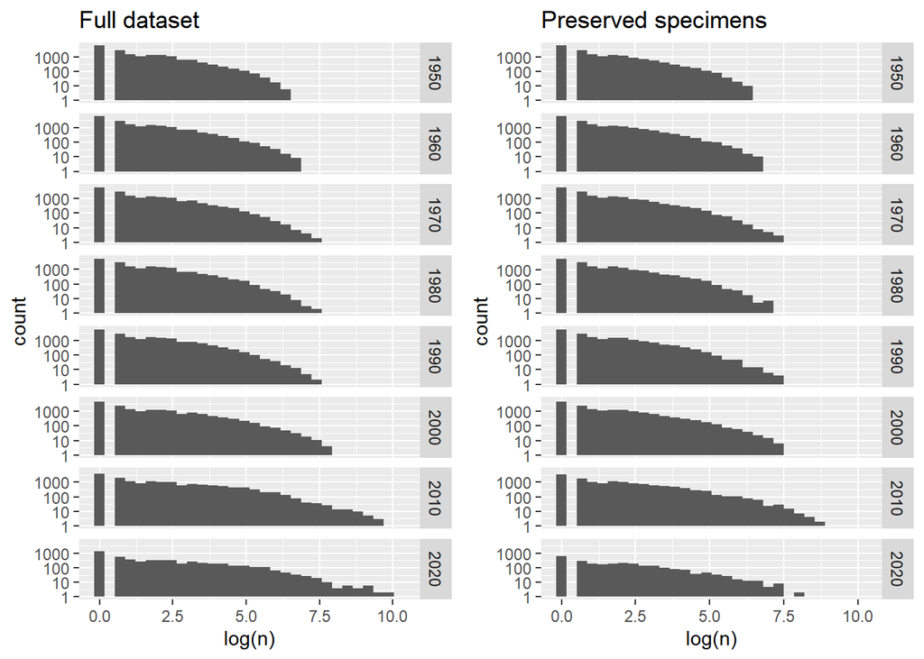

```r
#Count number of records by species and year (for full and specimens-only datasets)
bees_all_recs_by_sp_year <- bees_all %>%
  group_by(species, family, year, idecade) %>%
  count()

bees_prsv_recs_by_sp_year <- bees_all %>%
  filter(basisOfRecord=="PRESERVED_SPECIMEN")%>%
  group_by(species, family, year, idecade) %>%
  count()

#Histograms of abundance of records
g_recs_all_hist <-
ggplot(bees_all_recs_by_sp_year %>% filter(idecade>1940), aes(log(n))) +
  geom_histogram() +
  facet_grid(idecade~.) + scale_y_log10() +
  ggtitle("Full dataset")

g_recs_prsv_hist <-
ggplot(bees_prsv_recs_by_sp_year %>% filter(idecade>1940), aes(log(n))) +
  geom_histogram() +
  facet_grid(idecade~.) + scale_y_log10() +
  ggtitle("Preserved specimens")

grid.arrange(g_recs_all_hist, g_recs_prsv_hist, ncol =2)
```

The idecadal histograms of yearly record counts per species are similar with the full dataset showing longer tails of high counts in the last two idecades.

## Yearly trends

A table showing the yearly number of records, species, datasets, collections and institutions is built.

```r
#Count number of species per year (for complete and preserved specimens only datasets)
bees_all_sp_year <- bees_all_recs_by_sp_year %>%
  select(-n)  %>%
  group_by(year) %>%
  count() %>%
  rename(sp = n)

bees_prsv_sp_year <- bees_prsv_recs_by_sp_year %>%
  select(-n) %>%
  group_by(year) %>%
  count() %>%
  rename(sp = n)

#Count number of records per year (for complete and preserved specimens only datasets)
bees_all_recs_year <- bees_all %>%
  group_by(year) %>%
  count() %>%
  rename(records = n)

bees_prsv_recs_year <- bees_all %>%
  filter(basisOfRecord=="PRESERVED_SPECIMEN") %>%
  group_by(year) %>%
  count() %>%
  rename(records = n)

#Count number of datasets per year (for complete and preserved specimens only datasets)
bees_all_recs_by_dataset_year <- bees_all %>%
  group_by(year, datasetKey) %>%
  count()

bees_all_datasets_year <- bees_all_recs_by_dataset_year %>%
  select(-n) %>%
  group_by(year) %>%
  count() %>%
  rename(datasets = n)

bees_prsv_recs_by_dataset_year <- bees_all %>%
  filter(basisOfRecord=="PRESERVED_SPECIMEN") %>%
  group_by(year, datasetKey) %>%
  count()

bees_prsv_datasets_year <- bees_prsv_recs_by_dataset_year %>%
  select(-n) %>%
  group_by(year) %>%
  count() %>%
  rename(datasets = n)

#Count number of collections per year (for complete and preserved specimens only datasets)
bees_all_recs_by_collection_year <- bees_all %>%
  group_by(year, collectionCode) %>%
  count()

bees_all_collections_year <- bees_all_recs_by_collection_year %>%
  select(-n)  %>%
  group_by(year) %>%
  count() %>%
  rename(collections = n)

bees_prsv_recs_by_collection_year <- bees_all %>%
  filter(basisOfRecord=="PRESERVED_SPECIMEN") %>%
  group_by(year, collectionCode) %>%
  count()

bees_prsv_collection_year <- bees_prsv_recs_by_collection_year %>%
  select(-n) %>%
  group_by(year) %>%
  count() %>%
  rename(collections = n)

#Count number of institutions per year (for complete and preserved specimens only datasets)
bees_all_recs_by_institution_year <- bees_all %>%
  group_by(year, institutionCode) %>%
  count()

bees_all_institution_year <- bees_all_recs_by_institution_year %>%
  select(-n) %>%
  group_by(year) %>%
  count() %>%
  rename(institutions = n)

bees_prsv_recs_by_institution_year <- bees_all %>%
  filter(basisOfRecord=="PRESERVED_SPECIMEN") %>%
  group_by(year, institutionCode) %>%
  count()

bees_prsv_institution_year <- bees_prsv_recs_by_institution_year %>%
  select(-n) %>%
  group_by(year) %>%
  count() %>%
  rename(institutions = n)

#Merge all yearly counts
bees_all_gbif_year <- full_join(bees_all_sp_year, bees_all_recs_year, by = "year") %>%
  full_join(bees_all_datasets_year, by = "year") %>%
  full_join(bees_all_collections_year, by = "year") %>%
  full_join(bees_all_institution_year, by = "year")

bees_prsv_gbif_year <- full_join(bees_prsv_sp_year, bees_prsv_recs_year, by = "year") %>%
  full_join(bees_prsv_datasets_year, by = "year") %>%
  full_join(bees_prsv_collection_year, by = "year") %>%
  full_join(bees_prsv_institution_year, by = "year")
```

Each of the components of the yearly dataset (records, species, data providers) can be plotted for both the full and specimens-only datasets.

```r
#Plot number of records by year
plot_recs <-
ggplot() +
  geom_point(data = bees_all_recs_year %>% filter(year<2020, year>1900), aes(x = year, y = records), color = "#00AFBB") +
  geom_point(data = bees_all_recs_year %>% filter(year<2020, year>2015), aes(x = year, y = records+500), color = "black", shape = 8) +
  geom_smooth(data = bees_all_recs_year %>% filter(year<2016, year>1900), aes(x = year, y = records), color = "#00AFBB", fill = "lightblue") +
  geom_point(data = bees_prsv_recs_year %>% filter(year<2020, year>1900), aes(x = year, y = records), color = "red") +
  geom_point(data = bees_prsv_recs_year %>% filter(year<2020, year>2015), aes(x = year, y = records+500), color = "black", shape = 8) +
  geom_smooth(data = bees_prsv_recs_year %>% filter(year<2016, year>1900), aes(x = year, y = records), color = "red", fill = "pink") +
  ylab("No. records") + xlab("Year")


#Plot number of species by year
plot_sp <-
ggplot() +
  geom_point(data = bees_all_sp_year %>% filter(year<2020, year>1900), aes(x = year, y = sp), color = "#00AFBB") +
  geom_point(data = bees_all_sp_year %>% filter(year<2020, year>2015), aes(x = year, y = sp), color = "blue", shape = 19) +
  geom_point(data = bees_all_sp_year %>% filter(year<2020, year>2015), aes(x = year, y = sp+20), color = "black", shape = 8) +
  geom_smooth(data = bees_all_sp_year %>% filter(year<2016, year>1900), aes(x = year, y = sp), color = "#00AFBB", fill = "lightblue") +
  geom_point(data = bees_prsv_sp_year %>% filter(year<2020, year>1900), aes(x = year, y = sp), color = "red") +
  geom_point(data = bees_prsv_sp_year %>% filter(year<2020, year>2015), aes(x = year, y = sp), color = "darkred", shape = 19) +
  geom_point(data = bees_prsv_sp_year %>% filter(year<2020, year>2015), aes(x = year, y = sp+20), color = "black", shape = 8) +
  geom_smooth(data = bees_prsv_sp_year %>% filter(year<2016, year>1900), aes(x = year, y = sp), color = "red", fill = "pink") +
  ylab("species richness") + xlab("Year")


#Plot number of datasets by year
plot_datasets <-
ggplot() +
  geom_point(data = bees_all_datasets_year %>% filter(year<2020, year>1920), aes(x = year, y = datasets), color = "#00AFBB") +
  geom_smooth(data = bees_all_datasets_year %>% filter(year<2016, year>1920), aes(x = year, y = datasets), color = "#00AFBB", fill = "lightblue") +
  geom_point(data = bees_prsv_datasets_year %>% filter(year<2020, year>1920), aes(x = year, y = datasets), color = "red") +
  geom_smooth(data = bees_prsv_datasets_year %>% filter(year<2016, year>1920), aes(x = year, y = datasets), color = "red", fill = "pink") +
  ylim(0, max(bees_all_datasets_year$datasets)*1.05)

#Plot number of collections by year
plot_collections <-
ggplot() +
  geom_point(data = bees_all_collections_year %>% filter(year<2020, year>1920), aes(x = year, y = collections), color = "#00AFBB") +
  geom_smooth(data = bees_all_collections_year %>% filter(year<2016, year>1920), aes(x = year, y = collections), color = "#00AFBB", fill = "lightblue") +
  geom_point(data = bees_prsv_collection_year %>% filter(year<2020, year>1920), aes(x = year, y = collections), color = "red") +
  geom_smooth(data = bees_prsv_collection_year %>% filter(year<2016, year>1920), aes(x = year, y = collections), color = "red", fill = "pink")

#Plot number of institutions by year
plot_institutions <-
ggplot() +
  geom_point(data = bees_all_institution_year %>% filter(year<2020, year>1920), aes(x = year, y = institutions), color = "#00AFBB") +
  geom_smooth(data = bees_all_institution_year %>% filter(year<2016, year>1920), aes(x = year, y = institutions), color = "#00AFBB", fill = "lightblue") +
  geom_point(data = bees_prsv_institution_year %>% filter(year<2020, year>1920), aes(x = year, y = institutions), color = "red") +
  geom_smooth(data = bees_prsv_institution_year %>% filter(year<2016, year>1920), aes(x = year, y = institutions), color = "red", fill = "pink")
```

Plotting the total number of records per year in both datasets shows that the number of worldwide bee occurrence records follows a mostly monotonic increasing trend that becomes steeper after 1990. Since the four most recent years (2016-2019, marked with *) show a noticeable drop in records, likely due to time lags in data entry,<sup>5</sup> we excluded those years from further analyses to avoid a downward bias in the most recent years.

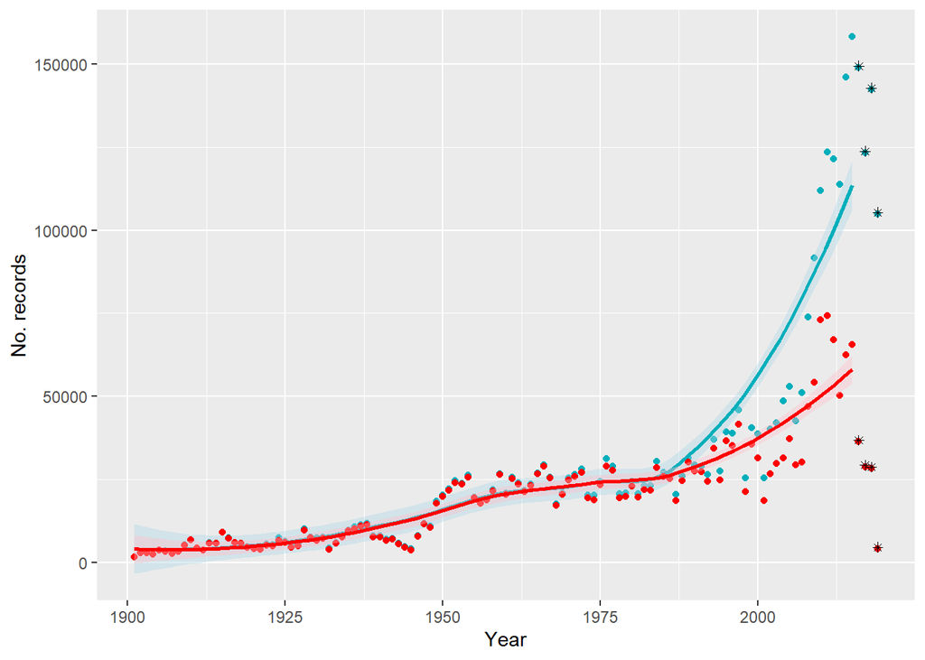

```r
plot_recs
```

In contrast, while the number of recorded species per year during the same period also increases initially, it reaches a steady maximum after 1950 but then shows a noticeable decline starting near the end of the 20th century.

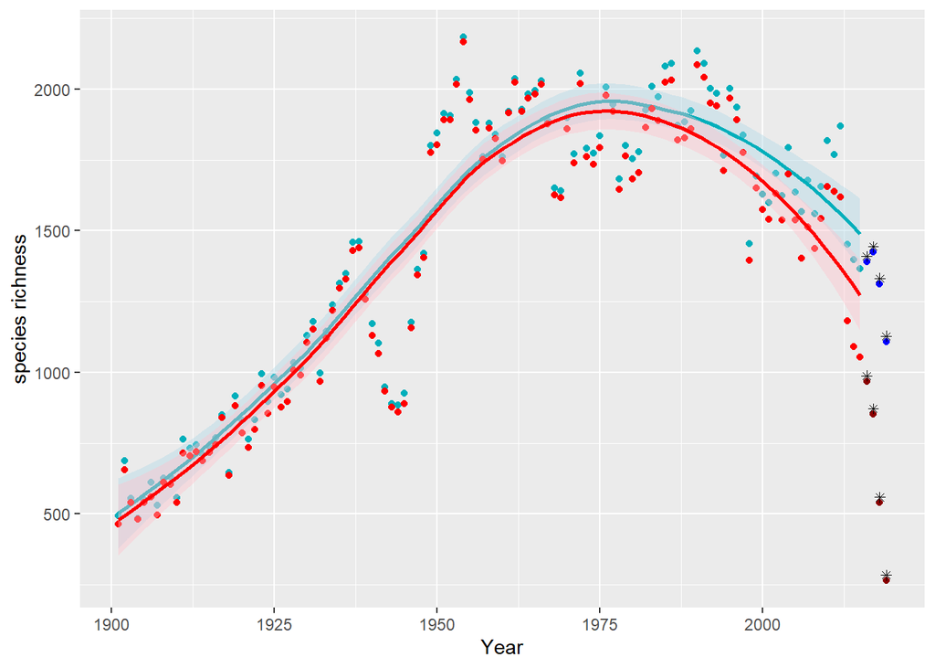

```r
plot_sp
```

Significance of a negative trend is tested by fitting yearly counts of records, species, collections, institutions and datasets a generalized least squares model with the formula `sp ~ year + records + collections + institutions + datasets`, with an autoregressive-moving average autocorrelation structure of order (1,0).

```r
# Generalized least squares with an autocorrelation-moving average correlation structure of order 1,0 on full dataset
bees_all_glsau <- gls(data=bees_all_gbif_year %>% filter(year>1985, year<2016),
                      sp ~  year+ records + collections + institutions + datasets,
                      correlation = corARMA(form = ~year, p=1, q=0))
summary(bees_all_glsau)
```

```
## Generalized least squares fit by REML
##   Model: sp ~ year + records + collections + institutions + datasets
##   Data: bees_all_gbif_year %>% filter(year > 1985, year < 2016)
##       AIC      BIC    logLik
##   373.971 383.3955 -178.9855
##
## Correlation Structure: AR(1)
##  Formula: ~year
##  Parameter estimate(s):
##       Phi
## 0.5145432
##
## Coefficients:
##                 Value Std.Error    t-value p-value
## (Intercept)  64945.17 21702.886  2.9924670  0.0063
## year           -31.91    10.996 -2.9016188  0.0078
## records          0.00     0.002  2.0963982  0.0468
## collections      1.26     1.293  0.9745077  0.3395
## institutions     5.59     4.005  1.3952718  0.1757
## datasets        -3.02     2.015 -1.4971250  0.1474
##
##  Correlation:
##              (Intr) year   recrds cllctn insttt
## year         -1.000
## records       0.724 -0.722
## collections   0.021 -0.020  0.206
## institutions  0.127 -0.143  0.024 -0.132
## datasets      0.380 -0.378 -0.002 -0.584 -0.298
##
## Standardized residuals:
##        Min         Q1        Med         Q3        Max
## -1.6795239 -0.5925350  0.1097958  0.6441571  1.4786917
##
## Residual standard error: 150.9122
## Degrees of freedom: 30 total; 24 residual
```

```r
# Generalized least squares with an autocorrelation-moving average correlation structure of order 1,0 on specimens-only dataset
bees_prsv_glsau <- gls(data=bees_prsv_gbif_year %>% filter(year>1985, year<2016),
                      sp ~  year+ records + collections + institutions + datasets,
                      correlation = corARMA(form = ~year, p=1, q=0))
summary(bees_prsv_glsau)
```

```
## Generalized least squares fit by REML
##   Model: sp ~ year + records + collections + institutions + datasets
##   Data: bees_prsv_gbif_year %>% filter(year > 1985, year < 2016)
##        AIC      BIC    logLik
##   362.1332 371.5577 -173.0666
##
## Correlation Structure: AR(1)
##  Formula: ~year
##  Parameter estimate(s):
##       Phi
## 0.6779421
##
## Coefficients:
##                 Value Std.Error   t-value p-value
## (Intercept)  82276.26 15879.274  5.181361  0.0000
## year           -40.88     7.903 -5.173022  0.0000
## records          0.01     0.003  4.335408  0.0002
## collections     -3.47     2.332 -1.488476  0.1496
## institutions     2.35     7.216  0.326163  0.7471
## datasets         7.84     5.207  1.505820  0.1452
##
##  Correlation:
##              (Intr) year   recrds cllctn insttt
## year         -1.000
## records       0.379 -0.392
## collections   0.017 -0.008 -0.371
## institutions -0.346  0.337  0.174 -0.470
## datasets      0.140 -0.153  0.109 -0.094 -0.590
##
## Standardized residuals:
##        Min         Q1        Med         Q3        Max
## -1.3626451 -0.3727025  0.1859463  0.6078703  1.5844935
##
## Residual standard error: 158.0478
## Degrees of freedom: 30 total; 24 residual
```

The results show that the negative temporal trend starting at the 1990’s idecade persists even when number of records and of contributing collections, institutions and datasets are considered (gls estimate + s.e. for the period 1986-2016: -31.907± 11.0, t value: -2.9, p = 0.008). Thus, fewer species have been reported globally within GBIF records since approximately the 1990s.

## Trends of records binned by idecade

Each year of data was assigned to a 10-year period termed “idecade” (for inter-decade), corresponding to a regular decade shifted four years into the past (e.g., the 1990’s idecade spans 1986 to 1995). Records by species and idecade are then counted and stored in a matrix of *m* species × 7 idecades (1950’s to 2010’s). This matrix is used as abundance data input for the iNEXT function of the iNEXT package<sup>6</sup> to estimate rarefaction-based interpolation/extrapolation (iNEXT) curves and Chao1 asymptotic estimators of species richness.<sup>5</sup>

```r
#Count number of records by species and idecade (for complete and preserved specimens only datasets)
bees_all_recs_by_sp_idec <- bees_all %>%
  group_by(species, family, idecade) %>%
  count()

bees_prsv_recs_by_sp_idec <- bees_all %>%
  filter(basisOfRecord=="PRESERVED_SPECIMEN")%>%
  group_by(species, family, idecade) %>%
  count()

#Generate idecadal matrices and calculate Chao stats
bees_all_recs_by_sp_idec.mat <-with(bees_all_recs_by_sp_idec %>% filter(idecade>1940, idecade<2020), as.data.frame(tapply(n, list(species,idecade),sum, na.rm=T)))
bees_all_recs_by_sp_idec.mat[is.na(bees_all_recs_by_sp_idec.mat)] <- 0
#bees_all_global_chao_idec <- iNEXT(bees_all_recs_by_sp_idec.mat, q=0, datatype = "abundance")
#save(bees_all_global_chao_idec, file="bees_all_global_chao_idec.Rdata")
load("bees_all_global_chao_idec.Rdata")

bees_prsv_recs_by_sp_idec.mat <-with(bees_prsv_recs_by_sp_idec %>% filter(idecade>1940, idecade<2020), as.data.frame(tapply(n, list(species,idecade),sum, na.rm=T)))
bees_prsv_recs_by_sp_idec.mat[is.na(bees_prsv_recs_by_sp_idec.mat)] <- 0
#bees_prsv_global_chao_idec <- iNEXT(bees_prsv_recs_by_sp_idec.mat, q=0, datatype = "abundance")
#save(bees_prsv_global_chao_idec, file="bees_prsv_global_chao_idec.Rdata")
load("bees_prsv_global_chao_idec.Rdata")
```

[figure not shown]

```r
# Plot iNEXT curves
plot_chao_prsv <-
  ggiNEXT(bees_prsv_global_chao_idec, type=1) +
  scale_shape_manual(values=c(19,19,19,19,19,19,19)) + xlim(0,1200000) +
  scale_colour_manual(values=viridis(length(levels(bees_prsv_global_chao_idec$AsyEst$Site)),direction=-1)) +
  theme(legend.position="none", axis.text=element_text(size=10),axis.title=element_text(size=12) ) +
  xlab("No. records (full dataset)") + ylab("Species richness")

plot_chao_all <-
  ggiNEXT(bees_all_global_chao_idec, type=1, ) +
  scale_shape_manual(values=c(19,19,19,19,19,19,19))  + xlim(0,1200000) +
  scale_colour_manual(values=viridis(length(levels(bees_all_global_chao_idec$AsyEst$Site)),direction=-1)) +
  theme(legend.position="none", axis.text=element_text(size=10),axis.title=element_text(size=12)) +
  xlab("No. records (specimens-only dataset)") + ylab("Species richness")

grid.arrange(plot_chao_all, plot_chao_prsv, ncol = 1)
```

Accumulation curves are informative about how well sampled a given idecade is, but the asymptotic estimates of species richness are less obvious. The estimate values and their confidence intervals can be extracted from the iNEXT objects.

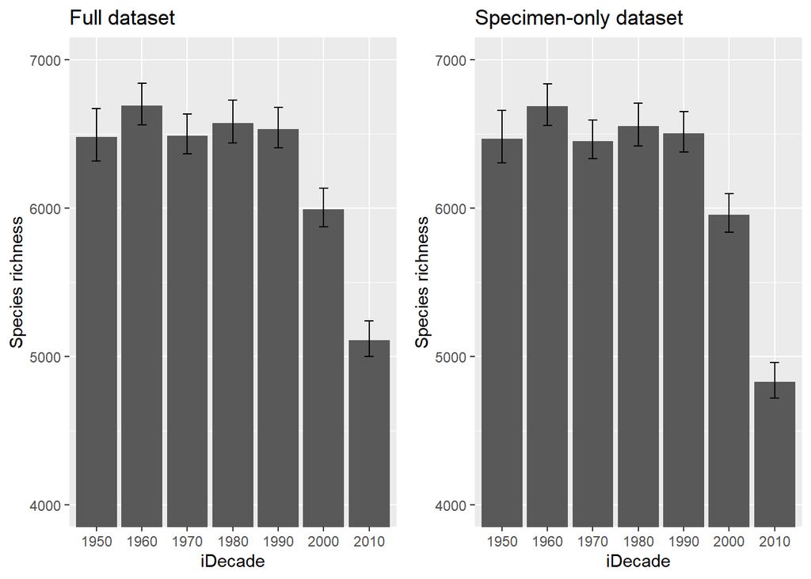

```r
# Extract and plot estimators as barplots

#Full dataset
chaoasyest_global_bees_all_idec <- bees_all_global_chao_idec$AsyEst[seq(1,21,3),]

plot_est_all <-
  ggplot(chaoasyest_global_bees_all_idec, aes(Site, Estimator)) +
  geom_bar(stat="Identity") +
  coord_cartesian(ylim = c(4000, 7000)) +
  geom_errorbar(aes(ymin=LCL, ymax=UCL), width=.2,
                position=position_dodge(.9)) +
  xlab("iDecade") + ylab("Species richness") +
  ggtitle("Full dataset")

#Specimens-only dataset
chaoasyest_global_bees_prsv_idec <- bees_prsv_global_chao_idec$AsyEst[seq(1,21,3),]

plot_est_prsv <-
ggplot(chaoasyest_global_bees_prsv_idec, aes(Site, Estimator)) +
  geom_bar(stat="Identity") +
  coord_cartesian(ylim = c(4000, 7000)) +
  geom_errorbar(aes(ymin=LCL, ymax=UCL), width=.2,
                position=position_dodge(.9)) +
  xlab("iDecade")  + ylab("Species richness") +
  ggtitle("Specimen-only dataset")

grid.arrange(plot_est_all, plot_est_prsv, nrow = 1)
```

The results show that species found in the full dataset during the 2000 idecade represent a decrease of 8.56% of the average estimate between 1946 and 1995, while in the 2010 idecade estimated richness decreased by 22.05% relative to the average estimate between 1946 and 1995.

For the specimens-only dataset, these values are 8.83% for the 2000 idecade, and 26.09% for the 2010 idecade.

These results suggest that the number of species among bee specimens collected worldwide is showing a sharp decline.

## Families

Bee families in the dataset are heterogeneous in terms of richness and abundance, and the observed trends might be driven by just a few bee clades. To make a more phylogenetically-explicit analysis exploring whether bees show a differential temporal trend compared to their closest relatives, and whether particular bee families are more endangered than others, we re-analyzed the specimen dataset, this time retaining also 0 records for two families of carnivorous apoid wasps, Crabronidae and Sphecidae, that are sister to Anthophila, and 0 records of another highly diverse, non-apoid hymenopteran family, the Formicidae (ants).<sup>7</sup> Phylogenetic relations between all families follow recent phylogenomics results.<sup>8</sup>

```r
# Re-read data from GBIF data file (WARNING: change nThread parameter to an appropriate value) for Anthophila+Outgroups,
# filtering out records without a species id
bwa_all <-fread(GBIFdata, select=fields, nThread=6) %>%
  filter(family %in% all_fams, taxonRank=="SPECIES", year!="", species!="")
bwa_all$idecade <- floor((bwa_all$year + 4)/10)*10
bwa_all$family <- factor(bwa_all$family,levels=all_fams)

bwa_prsv <- bwa_all %>% filter(basisOfRecord=="PRESERVED_SPECIMEN")

#Total Records per Family
records_per_fam <- bwa_all %>% group_by(family) %>% count()

#Count number of records by species and year (for complete and preserved specimens only datasets)
bwa_all_recs_by_sp_year <- bwa_all %>%
  group_by(species, family, year, idecade) %>%
  count()
bwa_prsv_recs_by_sp_year <- bwa_prsv %>%
  group_by(species, family, year, idecade) %>%
  count()

bwa_all_recs_year <- bwa_all_recs_by_sp_year %>%
  group_by(family, year) %>%
  count() %>%
  rename(records = n)

bwa_prsv_recs_year <- bwa_prsv_recs_by_sp_year %>%
  group_by(family, year) %>%
  count() %>%
  rename(records = n)
```

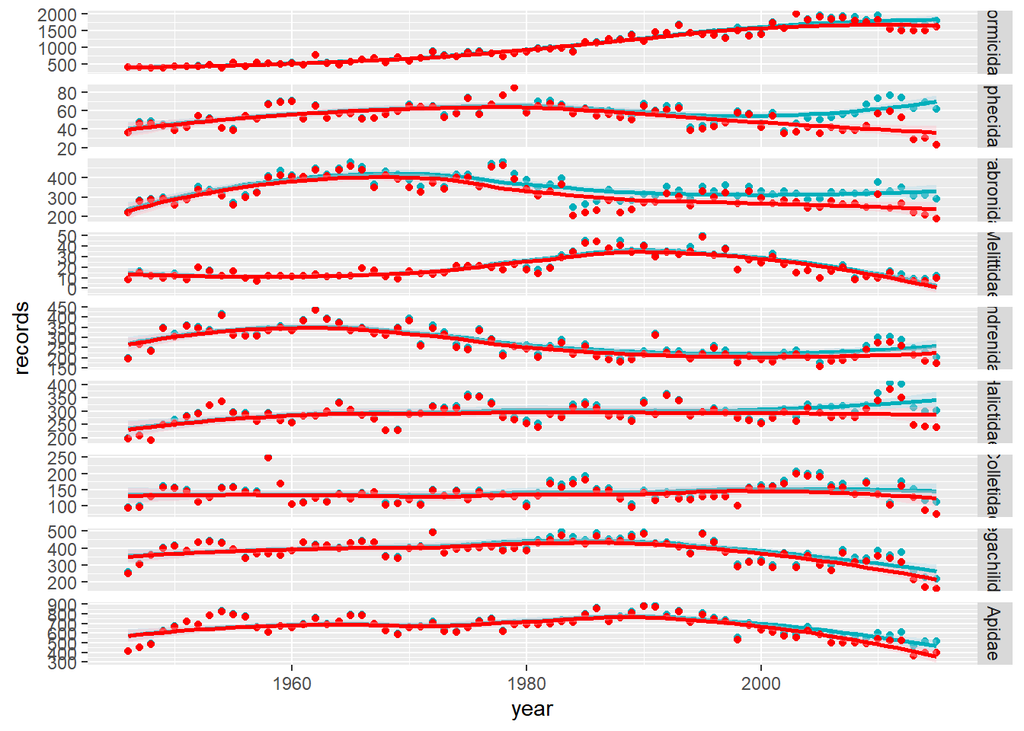

```r
#Plot number of records per year, by family, for full (blue) and specimen-only (red) datasets
ggplot() +
  geom_point(data = bwa_all_recs_year %>% filter(year<2016, year>1945), aes(x = year, y = records), color = "#00AFBB") +
  geom_smooth(data = bwa_all_recs_year %>% filter(year<2016, year>1945), aes(x = year, y = records), color = "#00AFBB", fill = "lightblue") +
  geom_point(data = bwa_prsv_recs_year %>% filter(year<2016, year>1945), aes(x = year, y = records), color = "red") +
  geom_smooth(data = bwa_prsv_recs_year %>% filter(year<2016, year>1945), aes(x = year, y = records), color = "red", fill = "pink") +
  facet_grid(family~., scales = "free")
```

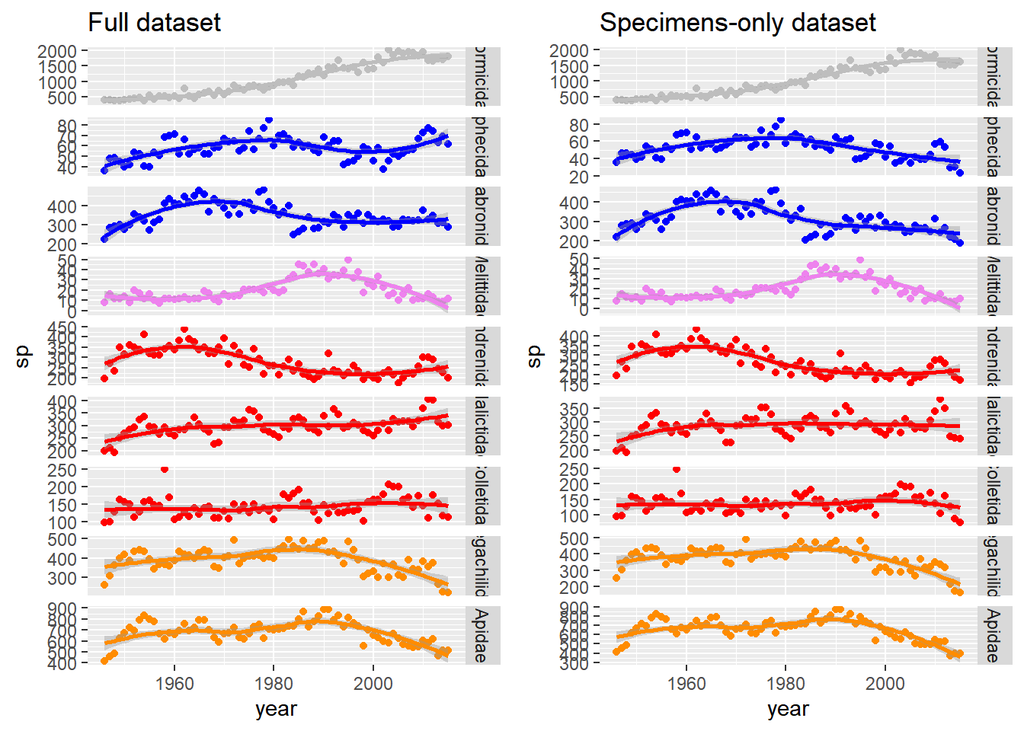

```r
#Count number of species by year, grouped by family (for complete and preserved specimens only datasets)
bwa_all_sp_year <- bwa_all_recs_by_sp_year  %>%
  select(-n)  %>%
  group_by(family, year) %>%
  count() %>%
  rename(sp = n)
bwa_prsv_sp_year <- bwa_prsv_recs_by_sp_year  %>%
  select(-n)  %>%
  group_by(family, year) %>%
  count() %>%
  rename(sp = n)

all_famcols=c("gray","blue","blue","violet","red","red","red","darkorange","darkorange")
names(all_famcols)<- all_fams

#Plot species per year, by family, full dataset
p_fam_sp_year_all <- ggplot(bwa_all_sp_year %>% filter(year<2016, year>1945), aes(x = year, y = sp, color = family)) +
  geom_point(show.legend = F)+
  geom_smooth(show.legend = F)+
  facet_grid(family~., scales = "free_y")+
  scale_color_manual(values = all_famcols) +
  ggtitle("Full dataset")

#Plot species per year, by family, specimen-only dataset
p_fam_sp_year_prsv <- ggplot(bwa_prsv_sp_year %>% filter(year<2016, year>1945), aes(x = year, y = sp, color = family)) +
  geom_point(show.legend = F)+
  geom_smooth(show.legend = F)+
  facet_grid(family~., scales = "free_y")+
  scale_color_manual(values = all_famcols) +
  ggtitle("Specimens-only dataset")

grid.arrange(p_fam_sp_year_all, p_fam_sp_year_prsv, ncol = 2)
```

Just as was done for the Anthophila dataset, records grouped by family can be binned into idecades, and used to draw species accumulation curves and asymptotic estimators of idecadal record richness.

```r
#Count number of records by species and idecade (for complete and preserved specimens only datasets)
bwa_all_recs_by_sp_idec <- bwa_all %>%
  group_by(species, family, idecade) %>%
  count()
bwa_prsv_recs_by_sp_idec <- bwa_prsv %>%
  group_by(species, family, idecade) %>%
  count()

#Then create an empty list to hold the iNEXT output for each family and run iNEXT in each family
#bwa_all_idec_chao <- list()
#for (i in all_fams)
#{
#  famdata <- with(bwa_all_recs_by_sp_idec %>%
#                    filter(idecade>1940, idecade<2020, family == i),
#                  as.data.frame(tapply(n, list(species,idecade),sum, na.rm=T)))
#  famdata[is.na(famdata)] <- 0
#  bwa_all_idec_chao[[i]] <- iNEXT(famdata, q=0, datatype = "abundance")
#}
#save(bwa_all_idec_chao, file = "bwa_all_idec_chao.Rdata")
load("bwa_all_idec_chao.Rdata")

#bwa_prsv_idec_chao <- list()
#for (i in all_fams)
#{
#  famdata <- with(bwa_prsv_recs_by_sp_idec %>%
#                    filter(idecade>1940, idecade<2020, family == i),
#                  as.data.frame(tapply(n, list(species,idecade),sum, na.rm=T)))
#  famdata[is.na(famdata)] <- 0
#  bwa_prsv_idec_chao[[i]] <- iNEXT(famdata, q=0, datatype = "abundance")
#}
#save(bwa_prsv_idec_chao, file = "bwa_prsv_idec_chao.Rdata")
load("bwa_prsv_idec_chao.Rdata")
```

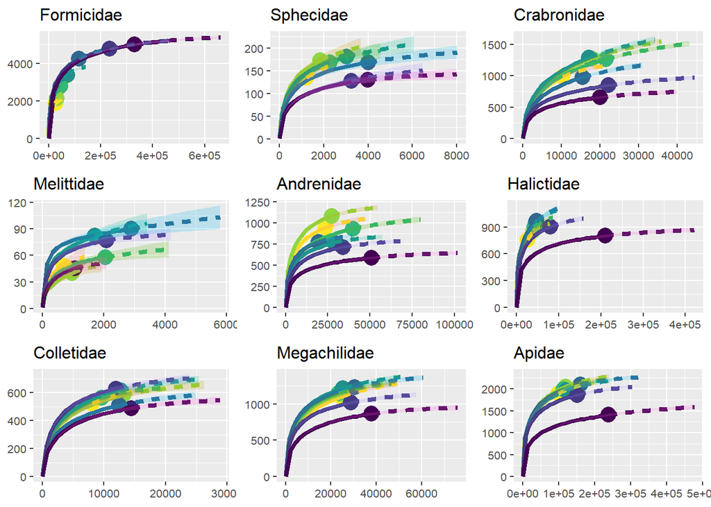

```r
for (i in all_fams){
  p <-
  ggiNEXT(bwa_prsv_idec_chao[[i]], type=1) +
  scale_shape_manual(values=c(16,16,16,16,16,16,16)) +
  scale_size_manual(values = rep(2,9)) +
  scale_colour_manual(values=viridis(length(levels(bwa_prsv_idec_chao[[i]]$AsyEst$Site)),direction=-1)) +
  theme(legend.position="none", axis.title.x = element_blank(),axis.title.y = element_blank(), text = element_text(size = 10)) +
          ggtitle(i)


  assign(paste0("chao_prsv_plot_", i), p)
}

grid.arrange(chao_prsv_plot_Formicidae,
             chao_prsv_plot_Sphecidae,
             chao_prsv_plot_Crabronidae,
             chao_prsv_plot_Melittidae,
             chao_prsv_plot_Andrenidae,
             chao_prsv_plot_Halictidae,
             chao_prsv_plot_Colletidae,
             chao_prsv_plot_Megachilidae,
             chao_prsv_plot_Apidae,
             ncol = 3)
```

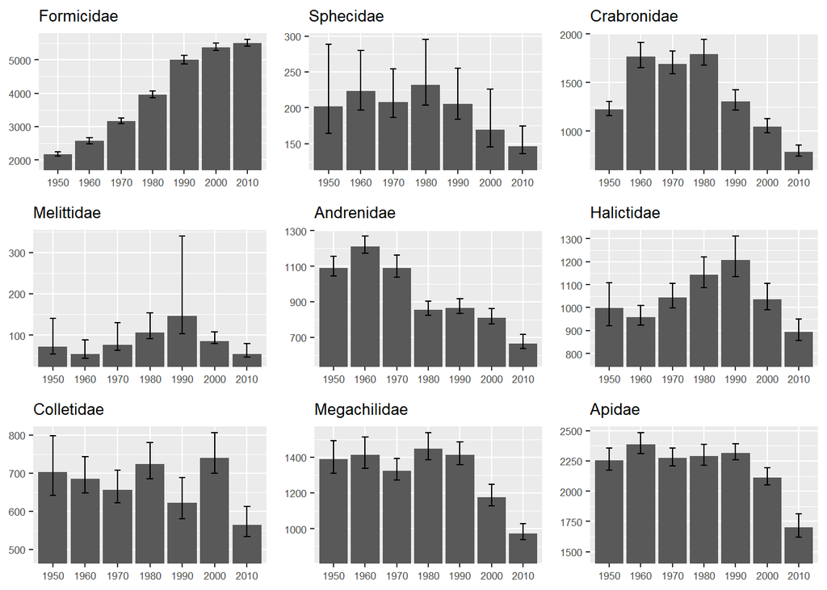

```r
for (i in all_fams){
  asyest <- bwa_prsv_idec_chao[[i]]$AsyEst[seq(1,21,3),]
  p <-
  ggplot(asyest, aes(Site, Estimator)) +
  geom_bar(stat="Identity") +
  coord_cartesian(ylim = c(0.9*min(asyest$LCL), max(asyest$UCL))) +
  geom_errorbar(aes(ymin=LCL, ymax=UCL), width=.2, position=position_dodge(.9)) +
  theme(legend.position="none", axis.title.x = element_blank(), axis.title.y = element_blank(), text = element_text(size = 8)) +
  ggtitle(i)
    assign(paste0("chao_prsv_est_", i), p)
}

grid.arrange(chao_prsv_est_Formicidae,
             chao_prsv_est_Sphecidae,
             chao_prsv_est_Crabronidae,
             chao_prsv_est_Melittidae,
             chao_prsv_est_Andrenidae,
             chao_prsv_est_Halictidae,
             chao_prsv_est_Colletidae,
             chao_prsv_est_Megachilidae,
             chao_prsv_est_Apidae,
             ncol = 3, nrow = 3)
```

Comparisons between Anthophila families and two families of apoid wasps sister to bees, and to a more distantly related family, the true ants (Formicidae), reveals contrasting trends. While both wasp families also show declining trends, they present different patterns than bees. Record richness of sphecid and crabronid wasps both show a smoother decrease initiating earlier than the 2000’s. In contrast, ants show very little evidence of global record richness decline, but rather a trend towards an increase in the number of recorded species.

Although the limited number of bee families precludes a formal analysis of phylogenetic patterning, closely related families (e.g., Apidae and Megachilidae, or Colletidae and Halictidae) seem to share more similar trends in terms of timing and magnitude of species richness decline than less related families. This hint of phylogenetic patterning becomes even more apparent when considering the two apoid wasp families, Crabronidae and Sphecidae.

Altogether, family-specific trends and asymptotic richness estimates show that the overall decline in global bee record richness is not driven by any particular family. Instead, a generalized decline seems to be a pervasive feature within the bee lineage.

## Testing asymptotic estimators by family

To rule out the possibility that the method we used to estimate richness does not correlate with actual bee diversity, we compared the asymptotic estimator of total richness for each family based on GBIF records with the total known number of species and found a linear correlation between both estimates across families.

```r
#Species counts obtained from the Integrated Taxonomic Information System (ITIS, www.itis.gov).
itis_sp_cts <-c(10213,784,8871,206,3010,4186,2493,5062,5677)
names(itis_sp_cts)<-all_fams

bwa_all_species_family <- bwa_all %>%
  group_by(species, family) %>%
  count()

#global_chao_fams <- list()
#for (i in all_fams)
#{
#  famdata <- bwa_all_species_family %>% filter(family==i)
#  famdata <- as.matrix(famdata[,c(-1,-2)])
#  global_chao_fams[[i]] <- iNEXT(famdata, q=0, datatype = "abundance")
#}
#save(global_chao_fams, file="global_chao_fams.Rdata")

load("global_chao_fams.Rdata")

chao_sp_cts <-as.numeric()
for(i in all_fams) {chao_sp_cts[i]<- global_chao_fams[[i]]$AsyEst[1,4]}
chao_sp_cts <-unlist(chao_sp_cts)

itis_chao <- bind_cols(as_tibble(cbind(itis_sp_cts, chao_sp_cts)), all_famcols)
```

```
## * NA -> ...3
```

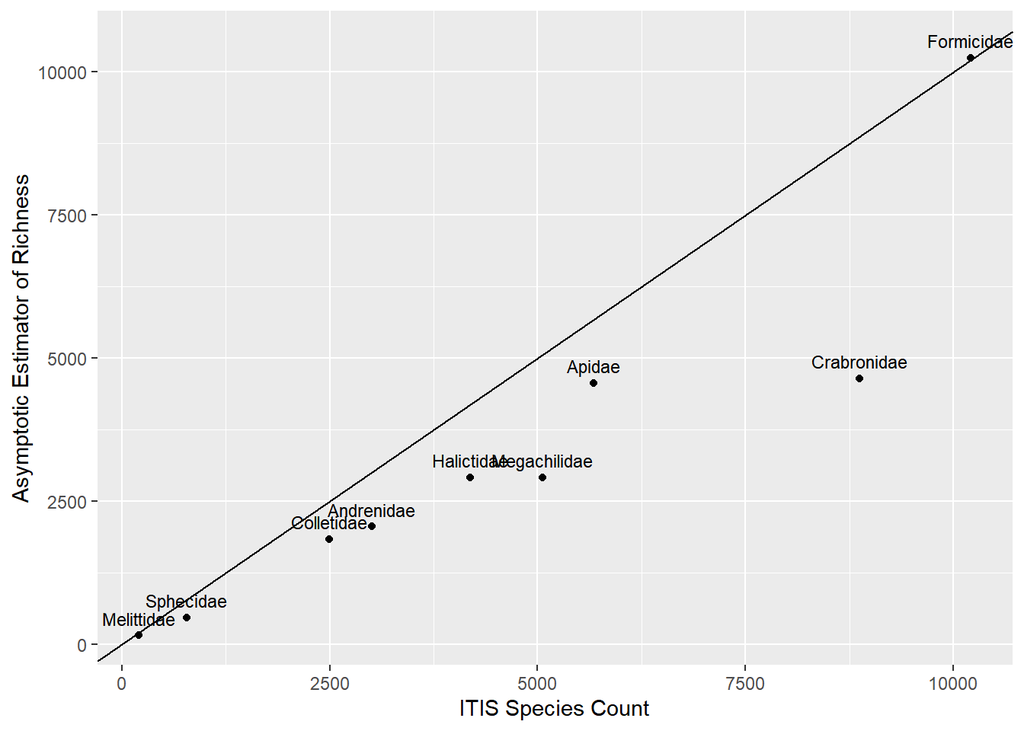

```r
names(itis_chao) <- c("itis","chao","Family")

ggplot(data= itis_chao, aes(x= itis, y=chao)) +
  geom_point() + xlab ("ITIS Species Count") +
  ylab("Asymptotic Estimator of Richness") +
  geom_text(aes(label = all_fams), nudge_y= 300, size=3) +
  geom_abline(slope = 1)
```

## Checking for loss of taxonomic expertise

Another potential artifact causing a decline in recorded bee diversity in the last two idecades could be an increasing loss in taxonomic expertise during that period.<sup>9–11</sup> Under such scenario, we would expect the fraction of records unidentified to the species level – a reasonable proxy for lack of expertise<sup>3</sup> – should have stayed approximately constant until the last two decades and then increased noticeably.

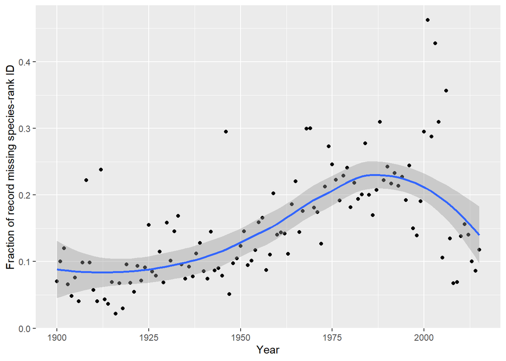

```r
#Filter anthophila families from unfiltered original GBIF data
bees_raw <-fread(GBIFdata, select=fields, nThread=6) %>%
  filter(family %in% anthophila_fams, year!="")

total_recs_year <- bees_raw %>%
  group_by(year) %>%
  count() %>%
  rename(all = n)
missid_year <- bees_raw %>%
  filter(taxonRank %in% c("GENUS","FAMILY", "UNRANKED")) %>%
  group_by(year) %>% count() %>%
  rename(misid = n)

missid_year <- right_join(missid_year, total_recs_year, by="year")
missid_year$fraction <- missid_year$misid/missid_year$all

# Plot
ggplot(missid_year %>% filter(year>1899, year<2016), aes(x = year, y = fraction)) +
  geom_point() +
  geom_smooth() +
  ylab("Fraction of record missing species-rank ID") + xlab("Year")
```

## Continent-level trends

Next, we explored the geographic distribution of the dataset by sub-setting the data by continent and repeating the analyses.

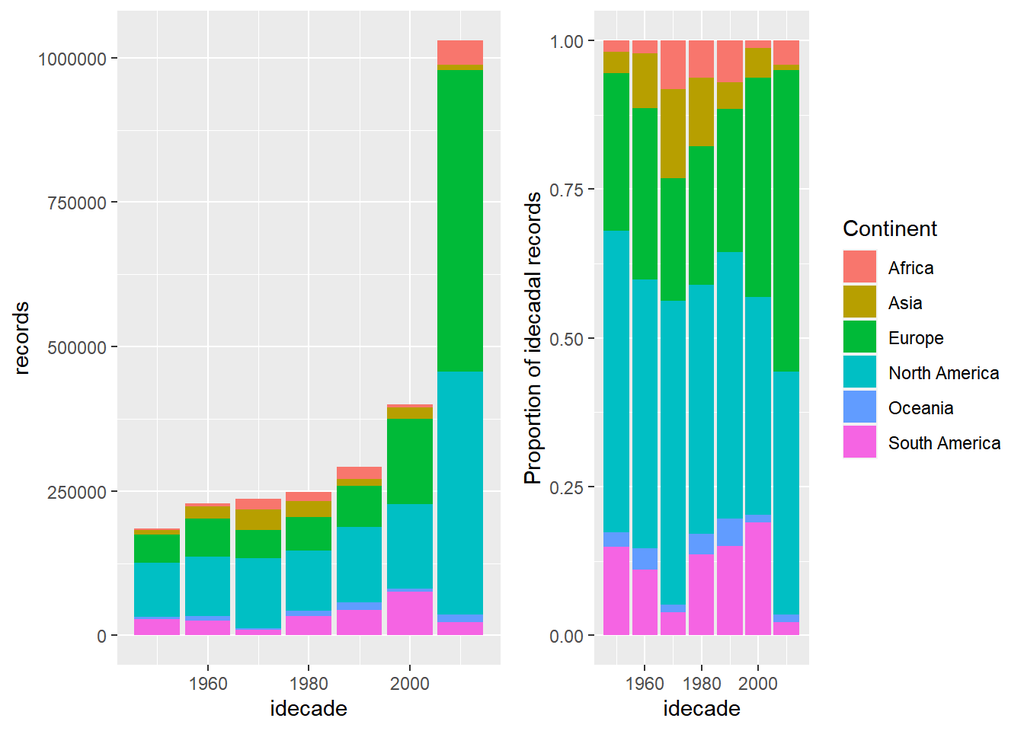

```r
continents <- c("Africa","Asia","Europe","North America","Oceania","South America")

#Count records per decade and continent
bees_all_cont <-left_join(bees_all %>% filter(countryCode!=""), country2continent, by="countryCode")
bees_all_cont_recs_by_sp_year <- bees_all_cont %>% group_by(species, Continent, year, idecade) %>% summarize(records = length(gbifID))
bees_prsv_cont_recs_by_sp_year <- bees_all_cont %>% filter(basisOfRecord=="PRESERVED_SPECIMEN")  %>% group_by(species, Continent, year, idecade) %>% summarize(records = length(gbifID))

#Count records per continent
bees_all_recs_by_cont <- bees_all_cont %>% filter(Continent %in% continents) %>% group_by(Continent, idecade) %>% summarize(records = length(gbifID))

#Plot Records By continent
cont_stack <- ggplot(data=bees_all_recs_by_cont %>% filter(idecade>1940, idecade<2020), aes(fill= Continent, y=records, x = idecade))+
  geom_bar(position="stack", stat="identity", show.legend = FALSE) +
  xlab("idecade")
cont_perc <- ggplot(data=bees_all_recs_by_cont %>% filter(idecade>1940, idecade<2020), aes(fill= Continent, y=records, x = idecade))+
  geom_bar(position="fill", stat="identity") +
  xlab("idecade") + ylab("Proportion of idecadal records")

# Plot continental contribution
grid.arrange(cont_stack, cont_perc, nrow = 1)
```

Overall, GBIF has a strong bias towards North American and European records<sup>5</sup>, and this bias results in a very uneven contribution of each continent to idecadal number of records.

```r
#Count number of species by year, grouped by continent (for complete and preserved specimens only datasets)
bees_all_cont_sp_year <- bees_all_cont_recs_by_sp_year  %>% select(-records)  %>% group_by(Continent, year) %>% count() %>% rename(sp = n)
bees_all_cont_recs_year <- bees_all_cont_recs_by_sp_year %>% group_by(Continent, year) %>% summarize(records = sum(records))

bees_prsv_cont_sp_year <- bees_prsv_cont_recs_by_sp_year  %>% select(-records)  %>% group_by(Continent, year) %>% count() %>% rename(sp = n)
bees_prsv_cont_recs_year <- bees_prsv_cont_recs_by_sp_year %>% group_by(Continent, year) %>% summarize(records = sum(records))

cont_recs <-
ggplot() +
  geom_point(data = bees_all_cont_recs_year %>% filter(year<2016, year>1945, !is.na(Continent)), aes(x = year, y = records), color = "#00AFBB") +
  geom_smooth(data = bees_all_cont_recs_year %>% filter(year<2016, year>1945, !is.na(Continent)), aes(x = year, y = records), color = "#00AFBB", fill = "lightblue") +
  geom_point(data = bees_prsv_cont_recs_year %>% filter(year<2016, year>1945, !is.na(Continent)), aes(x = year, y = records), color = "red") +
  geom_smooth(data = bees_prsv_cont_recs_year %>% filter(year<2016, year>1945, !is.na(Continent)), aes(x = year, y = records), color = "red", fill = "pink") +
  facet_grid(Continent~., scales = "free_y",  switch = "y") +
  theme(axis.title.x = element_blank(), axis.title.y = element_blank(), text = element_text(size = 12),  strip.background = element_blank(), strip.placement = "outside")


cont_sp <- ggplot() +
  geom_point(data = bees_all_cont_sp_year %>% filter(year<2016, year>1945, !is.na(Continent)), aes(x = year, y = sp), color = "#00AFBB") +
  geom_smooth(data = bees_all_cont_sp_year %>% filter(year<2016, year>1945, !is.na(Continent)), aes(x = year, y = sp), color = "#00AFBB", fill = "lightblue") +
  geom_point(data = bees_prsv_cont_sp_year %>% filter(year<2016, year>1945, !is.na(Continent)), aes(x = year, y = sp), color = "red") +
  geom_smooth(data = bees_prsv_cont_sp_year %>% filter(year<2016, year>1945, !is.na(Continent)), aes(x = year, y = sp), color = "red", fill = "pink") +
  facet_grid(Continent~., scales = "free_y") +
  theme(legend.position="none", axis.title.x = element_blank(),axis.title.y = element_blank(), text = element_text(size = 8), strip.background = element_blank(),strip.text.y = element_blank())
```

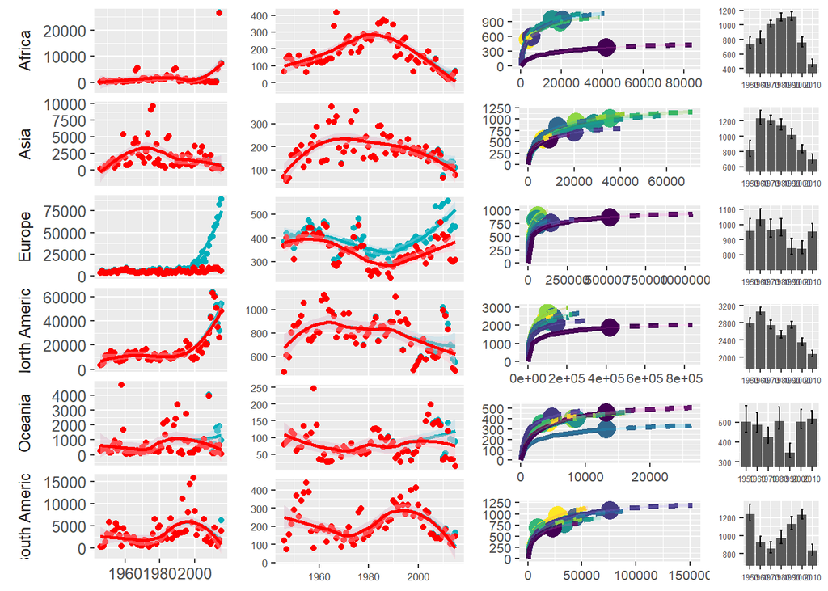

```r
## FULL dataset
#Create an empty list to hold the iNEXT output for each family and run iNEXT in each family
#cont_all_idec_chao <- list()
#for (i in continents)
#{
#  contdata <- with(bees_all_cont_recs_by_sp_year %>% filter(idecade>1940, idecade<2020, Continent == i), as.data.frame(tapply(records, list(species,idecade),sum, na.rm=T)))
#  contdata[is.na(contdata)] <- 0
#  cont_all_idec_chao[[i]] <- iNEXT(contdata, q=0, datatype = "abundance")
#}
#save(cont_all_idec_chao, file = "cont_all_idec_chao.Rdata")
load("cont_all_idec_chao.Rdata")

# Generate ggiNEXT plots for each continent
for (i in continents){
  p <-
    ggiNEXT(cont_all_idec_chao[[i]], type=1) +
    scale_shape_manual(values=c(16,16,16,16,16,16,16)) +
    scale_size_manual(values = rep(2,9)) +
    scale_colour_manual(values=viridis(length(levels(cont_all_idec_chao[[i]]$AsyEst$Site)),direction=-1)) +
    theme(legend.position="none", axis.title.x = element_blank(),axis.title.y = element_blank(), text = element_text(size = 10))
  assign(paste0("chao_all_plot_", sub(' ', '', i)), p)
}

# Extract idecadal richness estimator statistics for each continent and generate barplots
for (i in continents){
  asyest <- cont_all_idec_chao[[i]]$AsyEst[seq(1,21,3),]
  p <-
    ggplot(asyest, aes(Site, Estimator)) +
    geom_bar(stat="Identity") +
    coord_cartesian(ylim = c(0.9*min(asyest$LCL), max(asyest$UCL))) +
    geom_errorbar(aes(ymin=LCL, ymax=UCL), width=.2, position=position_dodge(.9)) +
    theme(legend.position="none", axis.title.x = element_blank(),axis.title.y = element_blank(), text = element_text(size = 6))
  assign(paste0("chao_all_est_",  sub(' ', '', i)), p)
}

# Arrange and display ggiNEXT plots for each continent
grid.arrange(cont_recs, cont_sp,
             chao_all_plot_Africa, #3
             chao_all_plot_Asia,
             chao_all_plot_Europe,
             chao_all_plot_NorthAmerica,
             chao_all_plot_Oceania,
             chao_all_plot_SouthAmerica,
             chao_all_est_Africa, #9
             chao_all_est_Asia,
             chao_all_est_Europe,
             chao_all_est_NorthAmerica,
             chao_all_est_Oceania,
             chao_all_est_SouthAmerica,
             widths = c(2, 2, 2, 1),
             layout_matrix = rbind(c(1, 2, 3, 9),
                                   c(1, 2, 4, 10),
                                   c(1, 2, 5, 11),
                                   c(1, 2, 6, 12),
                                   c(1, 2, 7, 13),
                                   c(1, 2, 8, 14)))
```

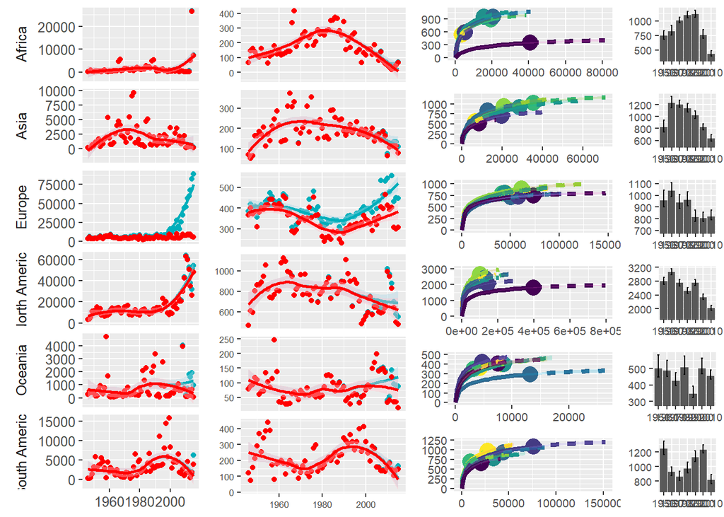

```r
# SPECIMEN dataset
#Create an empty list to hold the iNEXT output for each family and run iNEXT in each family
#cont_prsv_idec_chao <- list()
#for (i in continents)
#{
#  contdata <- with(bees_prsv_cont_recs_by_sp_year %>% filter(idecade>1940, idecade<2020, Continent == i), as.data.frame(tapply(records, list(species,idecade),sum, na.rm=T)))
#  contdata[is.na(contdata)] <- 0
#  cont_prsv_idec_chao[[i]] <- iNEXT(contdata, q=0, datatype = "abundance")
#}
#save(cont_prsv_idec_chao, file = "cont_prsv_idec_chao.Rdata")
load("cont_prsv_idec_chao.Rdata")

# Generate ggiNEXT plots for each continent
for (i in continents){
  p <-
    ggiNEXT(cont_prsv_idec_chao[[i]], type=1) +
    scale_shape_manual(values=c(16,16,16,16,16,16,16)) +
    scale_size_manual(values = rep(2,9)) +
    scale_colour_manual(values=viridis(length(levels(cont_prsv_idec_chao[[i]]$AsyEst$Site)),direction=-1)) +
    theme(legend.position="none", axis.title.x = element_blank(),axis.title.y = element_blank(), text = element_text(size = 10))
  assign(paste0("chao_prsv_plot_", sub(' ', '', i)), p)
}

# Extract idecadal richness estimator statistics for each continent and generate barplots
for (i in continents){
  asyest <- cont_prsv_idec_chao[[i]]$AsyEst[seq(1,21,3),]
  p <-
    ggplot(asyest, aes(Site, Estimator)) +
    geom_bar(stat="Identity") +
    coord_cartesian(ylim = c(0.9*min(asyest$LCL), max(asyest$UCL))) +
    geom_errorbar(aes(ymin=LCL, ymax=UCL), width=.2, position=position_dodge(.9)) +
    theme(legend.position="none", axis.title.x = element_blank(),axis.title.y = element_blank(), text = element_text(size = 9))
  assign(paste0("chao_prsv_est_",  sub(' ', '', i)), p)
}

# Multipanel figure for continent-level analyses
grid.arrange(cont_recs, cont_sp,
             chao_prsv_plot_Africa, #3
             chao_prsv_plot_Asia,
             chao_prsv_plot_Europe,
             chao_prsv_plot_NorthAmerica,
             chao_prsv_plot_Oceania,
             chao_prsv_plot_SouthAmerica,
             chao_prsv_est_Africa, #9
             chao_prsv_est_Asia,
             chao_prsv_est_Europe,
             chao_prsv_est_NorthAmerica,
             chao_prsv_est_Oceania,
             chao_prsv_est_SouthAmerica,
             widths = c(2, 2, 2, 1),
             layout_matrix = rbind(c(1, 2, 3, 9),
                                   c(1, 2, 4, 10),
                                   c(1, 2, 5, 11),
                                   c(1, 2, 6, 12),
                                   c(1, 2, 7, 13),
                                   c(1, 2, 8, 14)))
```

Overall, analyses of the dataset at a continental scale show heterogeneity in both the proportional and absolute contributions to the records, and in the timing and magnitude of the decline in species richness. However, despite large differences in data availability, all continents except for Oceania seem to be contributing to the observed global decline in species richness of bee records.

## Trends in record eveness

A global decline in bee record diversity could relate to a proportional decrease in bee abundance, so that rare species become rarer or even extinct, and abundant species become less abundant. Alternatively, the less abundant species could be declining strongly, whereas abundant species might be declining at a lower rate or even thriving. These different scenarios are expected to leave a distinctive signature in the temporal pattern of relative record abundances. Under the first scenario, the sharp decrease in species richness estimates should not be accompanied by a decrease in evenness, a measure of how equally total record abundance is partitioned among species, whereas under the second scenario there should be a parallel decrease in record evenness.

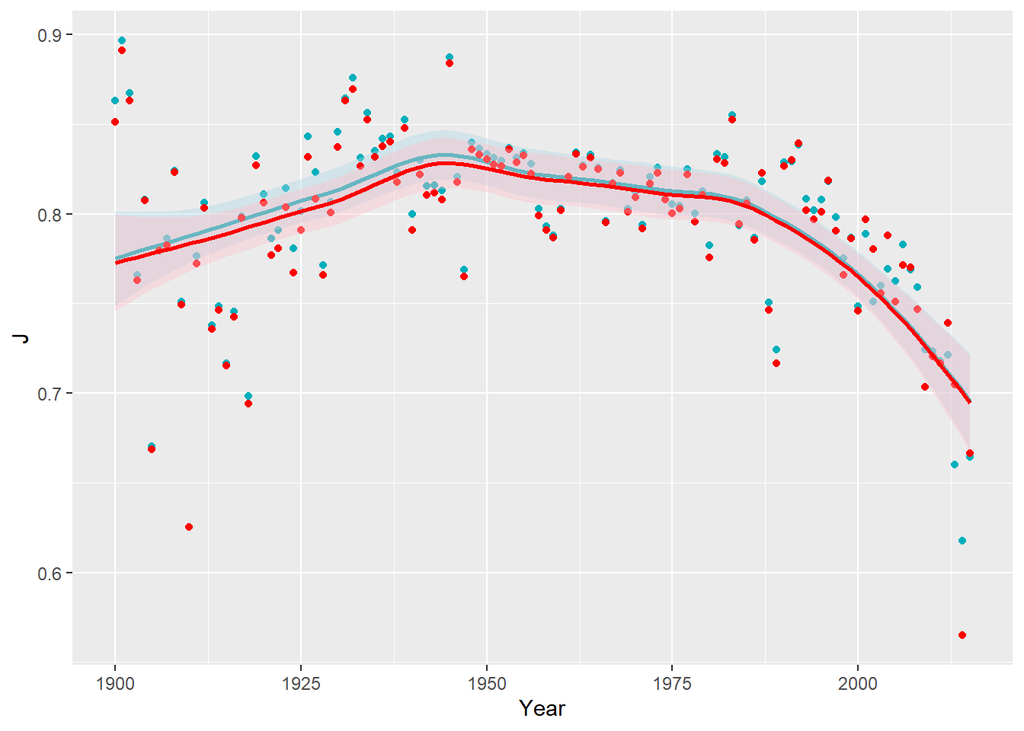

```r
#FULL dataset
bees_all_species_year_table <- xtabs(~year + species, data = bees_all %>%
                                       filter(year>1899, year<2016))
year <- bees_all %>%
  filter(year>1899, year<2016) %>%
  select(year) %>%
  unique()
H_all <- diversity(bees_all_species_year_table)
J_all <- H_all/log(specnumber(bees_all_species_year_table))

years <- names(J_all)
J_all_tbl <- as_tibble(cbind(as.numeric(years), as.numeric(J_all)))
colnames(J_all_tbl)<-c("year", "J")

#SPECIMEN dataset
bees_prsv_species_year_table <- xtabs(~year + species, data = bees_all %>%
                         filter(year>1899, year<2016, basisOfRecord=="PRESERVED_SPECIMEN"))
year_prsv <- bees_all %>%
  filter(year>1899, year<2016, basisOfRecord=="PRESERVED_SPECIMEN") %>%
  select(year) %>%
  unique()
H_prsv <- diversity(bees_prsv_species_year_table)
J_prsv <- H_prsv/log(specnumber(bees_prsv_species_year_table))

years <- names(J_prsv)
J_prsv_tbl <- as_tibble(cbind(as.numeric(years), as.numeric(J_prsv)))
colnames(J_prsv_tbl)<-c("year", "J")

#Plot J over time for both datasets
ggplot() +
  geom_point(data = J_all_tbl, aes(x = year, y = J), color = "#00AFBB") +
  geom_smooth(data = J_all_tbl, aes(x = year, y = J), color = "#00AFBB", fill = "lightblue") +
  geom_point(data = J_prsv_tbl, aes(x = year, y = J), color = "red") +
  geom_smooth(data = J_prsv_tbl, aes(x = year, y = J), color = "red", fill = "pink") +
  xlab("Year")
```

As expected from the hypothesis of an abundance-related differential species decline, plotting Pielou’s index (a common measure of evenness<sup>12</sup>) per year of bee records shows a strong decreasing trend since the 1990’s for both datasets. Therefore, this decline in species richness of records can relate to either a global change in how an invariant bee diversity is sampled, leading to more infrequent reporting of many species and much more frequent reporting of a few other species, or to a global phenomenon by which thousands of species are becoming too rare to be sampled while fewer species are becoming dominant and perhaps even increasing in abundance. These two alternatives are not mutually exclusive, but the global trend of decreasing evenness is consistent with reported regional trends of increasing dominance by one or a few bee species associated with large-scale anthropogenic disturbance.<sup>13,14</sup>

## Dataset dominance by *Apis mellifera*

Associated with the declining trend of richness of species records is a trend of increasing dominance of records by a few species. Increasing dominance by one or a few species can be observed at the regional scale, like the case of *Bombus terrestris* in Scandinavia, within its native geographical range,<sup>13</sup> and in southern South America, within its invaded range,<sup>15</sup> or the western honeybee *Apis mellifera* in the Mediterranean.<sup>14</sup> In particular, the western honeybee has been introduced in every single continent from its original geographical range in Europe and Africa. Although both domesticated and wild populations of the western honeybee seem to be declining in several countries, this species is still thriving globally.<sup>16</sup>

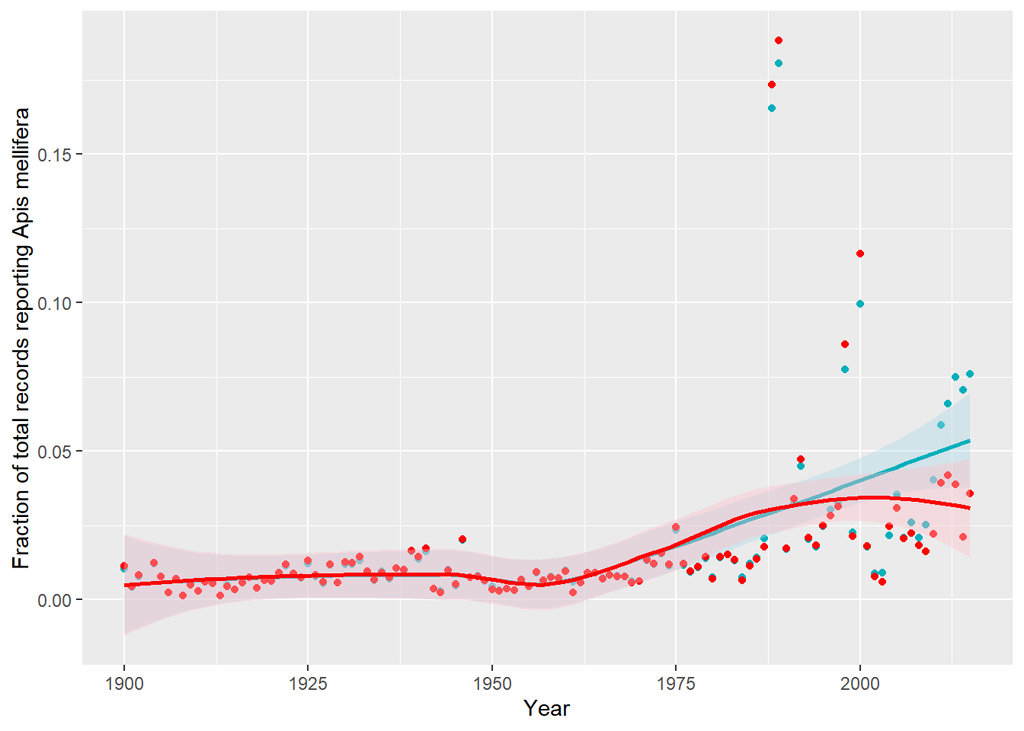

```r
apis_all_recs_by_year <- right_join(bees_all_recs_year, bees_all_recs_by_sp_year %>% filter(species=="Apis mellifera"), by="year")
apis_all_recs_by_year <- apis_all_recs_by_year %>% mutate(fraction = n / records)

apis_prsv_recs_by_year <- right_join(bees_prsv_recs_year, bees_prsv_recs_by_sp_year %>% filter(species=="Apis mellifera"), by="year")
apis_prsv_recs_by_year <- apis_prsv_recs_by_year %>% mutate(fraction = n / records)

ggplot() +
  geom_point(data = apis_all_recs_by_year %>% filter(year>1899, year<2016), aes(x = year, y = fraction), color = "#00AFBB") +
  geom_smooth(data = apis_all_recs_by_year %>% filter(year>1899, year<2016), aes(x = year, y = fraction), color = "#00AFBB", fill = "lightblue") +
  geom_point(data = apis_prsv_recs_by_year %>% filter(year>1899, year<2016), aes(x = year, y = fraction), color = "red") +
  geom_smooth(data = apis_prsv_recs_by_year %>% filter(year>1899, year<2016), aes(x = year, y = fraction), color = "red", fill = "pink")+
  xlab("Year") + ylab("Fraction of total records reporting Apis mellifera")
```

Correspondingly, an increasing fraction of the total global bee records is composed of *Apis mellifera* occurrences. A consequence of increasingly less diverse and uneven bee assemblages could be an increase in pollination deficits, causing a reduction in the quantity and quality of the fruits and seeds produced by both wild and cultivated plants. Less diverse bee assemblages at both local and regional scales have been associated with lower and less stable yields of most pollinator-dependent crops.<sup>17</sup>

## Country level datasets

Unsurprisingly, when data is disaggregated by country, agreement between country-level results and existing reports improves as the number of records increases.

```r
####United States of America ----
bees_us_recs_by_sp_year <- bees_all %>% filter(countryCode=="US", basisOfRecord=="PRESERVED_SPECIMEN") %>% group_by(species, family, year, idecade) %>% count()
bees_us_recs_year <- bees_all  %>% filter(countryCode=="US", basisOfRecord=="PRESERVED_SPECIMEN") %>% group_by(year) %>% count() %>% rename(records = n)
bees_us_sp_year <- bees_us_recs_by_sp_year %>% select(-n)  %>% group_by(year) %>% count() %>% rename(sp = n)

bees_us_recs_sp_by_year <- inner_join(bees_us_recs_year, bees_us_sp_year, by="year")

plot_us_recs <-
  ggplot(data = bees_us_recs_sp_by_year %>% filter(year>1899, year<2016), aes(x = year, y = records)) +
  geom_point() +
  geom_smooth() +
  xlab("Year") + ylab("No. records")
plot_us_sp <-
ggplot(data = bees_us_recs_sp_by_year %>% filter(year>1899, year<2016), aes(x = year, y = sp)) +
  geom_point() +
  geom_smooth() +
  xlab("Year") + ylab("Species richness")

sum(bees_us_recs_sp_by_year$records) # Total number of records
```

```
## [1] 1030029
```

```r
#Count number of records by species and idecade
bees_us_recs_by_sp_idec <- bees_all %>% filter(countryCode=="US", basisOfRecord=="PRESERVED_SPECIMEN") %>% group_by(species, family, idecade) %>% count()

#Generate idecadal matrices and calculate Chao stats
bees_us_recs_by_sp_idec.mat <-with(bees_us_recs_by_sp_idec %>% filter(idecade>1940, idecade<2020), as.data.frame(tapply(n, list(species,idecade),sum, na.rm=T)))
bees_us_recs_by_sp_idec.mat[is.na(bees_us_recs_by_sp_idec.mat)] <- 0
bees_us_chao_idec <- iNEXT(bees_us_recs_by_sp_idec.mat, q=0, datatype = "abundance")

#iNEXT curves
plot_chao_us <-
  ggiNEXT(bees_us_chao_idec, type=1) +
  scale_shape_manual(values=c(19,19,19,19,19,19,19)) + xlim(0,4e+05) +
  scale_colour_manual(values=viridis(length(levels(bees_us_chao_idec$AsyEst$Site)),direction=-1)) +
  theme(legend.position="none", axis.text=element_text(size=10),axis.title=element_text(size=12) ) +
  xlab("No. records") + ylab("Species richness")

#Extract and plot estimators as barplots
chaoasyest_us_bees_idec <- bees_us_chao_idec$AsyEst[seq(1,21,3),]

plot_est_us <-
  ggplot(chaoasyest_us_bees_idec, aes(Site, Estimator)) +
  geom_bar(stat="Identity") +
  coord_cartesian(ylim = c(min(chaoasyest_us_bees_idec$LCL*0.5), max(chaoasyest_us_bees_idec$UCL))) +
    geom_errorbar(aes(ymin=LCL, ymax=UCL), width=.2,
                position=position_dodge(.9)) +
  xlab("idecade")  + ylab("Species richness")
```

```r
####Brazil
bees_br_recs_by_sp_year <- bees_all %>% filter(countryCode=="BR", basisOfRecord=="PRESERVED_SPECIMEN") %>% group_by(species, family, year, idecade) %>% count()
bees_br_recs_year <- bees_all  %>% filter(countryCode=="BR", basisOfRecord=="PRESERVED_SPECIMEN") %>% group_by(year) %>% count() %>% rename(records = n)
bees_br_sp_year <- bees_br_recs_by_sp_year %>% select(-n)  %>% group_by(year) %>% count() %>% rename(sp = n)

bees_br_recs_sp_by_year <- inner_join(bees_br_recs_year, bees_br_sp_year, by="year")

plot_br_recs <-
  ggplot(data = bees_br_recs_sp_by_year %>% filter(year>1899, year<2016), aes(x = year, y = records)) +
  geom_point() +
  geom_smooth() +
  xlab("Year") + ylab("No. records")
plot_br_sp <-
  ggplot(data = bees_br_recs_sp_by_year %>% filter(year>1899, year<2016), aes(x = year, y = sp)) +
  geom_point() +
  geom_smooth() +
  xlab("Year") + ylab("Species richness")

sum(bees_br_recs_sp_by_year$records) # Total number of records
```

```
## [1] 188788
```

```r
#Count number of records by species and idecade
bees_br_recs_by_sp_idec <- bees_all %>% filter(countryCode=="BR", basisOfRecord=="PRESERVED_SPECIMEN") %>% group_by(species, family, idecade) %>% count()

#Generate idecadal matrices and calculate Chao stats
bees_br_recs_by_sp_idec.mat <-with(bees_br_recs_by_sp_idec %>% filter(idecade>1940, idecade<2020), as.data.frame(tapply(n, list(species,idecade),sum, na.rm=T)))
bees_br_recs_by_sp_idec.mat[is.na(bees_br_recs_by_sp_idec.mat)] <- 0
bees_br_chao_idec <- iNEXT(bees_br_recs_by_sp_idec.mat, q=0, datatype = "abundance")

#iNEXT curves
plot_chao_br <-
  ggiNEXT(bees_br_chao_idec, type=1) +
  scale_shape_manual(values=c(19,19,19,19,19,19,19)) +
  scale_colour_manual(values=viridis(length(levels(bees_br_chao_idec$AsyEst$Site)),direction=-1)) +
  theme(legend.position="none", axis.text=element_text(size=10),axis.title=element_text(size=12) ) +
  xlab("No. records") + ylab("Species richness")

#Extract and plot estimators as barplots
chaoasyest_br_bees_idec <- bees_br_chao_idec$AsyEst[seq(1,21,3),]

plot_est_br <-
  ggplot(chaoasyest_br_bees_idec, aes(Site, Estimator)) +
  geom_bar(stat="Identity") +
  coord_cartesian(ylim = c(min(chaoasyest_br_bees_idec$LCL*0.5), max(chaoasyest_br_bees_idec$UCL))) +
  geom_errorbar(aes(ymin=LCL, ymax=UCL), width=.2,
                position=position_dodge(.9)) +
  xlab("idecade")  + ylab("Species richness")
```

```r
####Great Britain ----
bees_gb_recs_by_sp_year <- bees_all %>% filter(countryCode=="GB", basisOfRecord=="PRESERVED_SPECIMEN") %>% group_by(species, family, year, idecade) %>% count()
bees_gb_recs_year <- bees_all  %>% filter(countryCode=="GB", basisOfRecord=="PRESERVED_SPECIMEN") %>% group_by(year) %>% count() %>% rename(records = n)
bees_gb_sp_year <- bees_gb_recs_by_sp_year %>% select(-n)  %>% group_by(year) %>% count() %>% rename(sp = n)

bees_gb_recs_sp_by_year <- inner_join(bees_gb_recs_year, bees_gb_sp_year, by="year")

plot_gb_recs <-
  ggplot(data = bees_gb_recs_sp_by_year %>% filter(year>1899, year<2016), aes(x = year, y = records)) +
  geom_point() +
  geom_smooth() +
  xlab("Year") + ylab("No. records")
plot_gb_sp <-
  ggplot(data = bees_gb_recs_sp_by_year %>% filter(year>1899, year<2016), aes(x = year, y = sp)) +
  geom_point() +
  geom_smooth() +
  xlab("Year") + ylab("Species richness")

sum(bees_gb_recs_sp_by_year$records) # Total number of records
```

```
## [1] 26885
```

```r
#Count number of records by species and idecade
bees_gb_recs_by_sp_idec <- bees_all %>% filter(countryCode=="GB", basisOfRecord=="PRESERVED_SPECIMEN") %>% group_by(species, family, idecade) %>% count()

#Generate idecadal matrices and calculate Chao stats
bees_gb_recs_by_sp_idec.mat <-with(bees_gb_recs_by_sp_idec %>% filter(idecade>1940, idecade<2020), as.data.frame(tapply(n, list(species,idecade),sum, na.rm=T)))
bees_gb_recs_by_sp_idec.mat[is.na(bees_gb_recs_by_sp_idec.mat)] <- 0
bees_gb_chao_idec <- iNEXT(bees_gb_recs_by_sp_idec.mat, q=0, datatype = "abundance")

#iNEXT curves
plot_chao_gb <-
  ggiNEXT(bees_gb_chao_idec, type=1) +
  scale_shape_manual(values=c(19,19,19,19,19,19,19)) +
  scale_colour_manual(values=viridis(length(levels(bees_gb_chao_idec$AsyEst$Site)),direction=-1)) +
  theme(legend.position="none", axis.text=element_text(size=10),axis.title=element_text(size=12) ) +
  xlab("No. records") + ylab("Species richness")

#Extract and plot estimators as barplots
chaoasyest_gb_bees_idec <- bees_gb_chao_idec$AsyEst[seq(1,21,3),]

plot_est_gb <-
  ggplot(chaoasyest_gb_bees_idec, aes(Site, Estimator)) +
  geom_bar(stat="Identity") +
  coord_cartesian(ylim = c(min(chaoasyest_gb_bees_idec$LCL*0.5), max(chaoasyest_gb_bees_idec$UCL))) +
  geom_errorbar(aes(ymin=LCL, ymax=UCL), width=.2,
                position=position_dodge(.9)) +
  xlab("idecade")  + ylab("Species richness")
```

```r
####Panama  ----
bees_pa_recs_by_sp_year <- bees_all %>% filter(countryCode=="PA", basisOfRecord=="PRESERVED_SPECIMEN") %>% group_by(species, family, year, idecade) %>% count()
bees_pa_recs_year <- bees_all  %>% filter(countryCode=="PA", basisOfRecord=="PRESERVED_SPECIMEN") %>% group_by(year) %>% count() %>% rename(records = n)
bees_pa_sp_year <- bees_pa_recs_by_sp_year %>% select(-n)  %>% group_by(year) %>% count() %>% rename(sp = n)

bees_pa_recs_sp_by_year <- inner_join(bees_pa_recs_year, bees_pa_sp_year, by="year")

plot_pa_recs <-
  ggplot(data = bees_pa_recs_sp_by_year %>% filter(year>1899, year<2016), aes(x = year, y = records)) +
  geom_point() +
  geom_smooth() +
  xlab("Year") + ylab("No. records")
plot_pa_sp <-
  ggplot(data = bees_pa_recs_sp_by_year %>% filter(year>1899, year<2016), aes(x = year, y = sp)) +
  geom_point() +
  geom_smooth() +
  xlab("Year") + ylab("Species richness")

sum(bees_pa_recs_sp_by_year$records) # Total number of records
```

```
## [1] 8892
```

```r
#Count number of records by species and idecade
bees_pa_recs_by_sp_idec <- bees_all %>% filter(countryCode=="PA", basisOfRecord=="PRESERVED_SPECIMEN") %>% group_by(species, family, idecade) %>% count()

#Generate idecadal matrices and calculate Chao stats
bees_pa_recs_by_sp_idec.mat <-with(bees_pa_recs_by_sp_idec %>% filter(idecade>1940, idecade<2020), as.data.frame(tapply(n, list(species,idecade),sum, na.rm=T)))
bees_pa_recs_by_sp_idec.mat[is.na(bees_pa_recs_by_sp_idec.mat)] <- 0
bees_pa_chao_idec <- iNEXT(bees_pa_recs_by_sp_idec.mat, q=0, datatype = "abundance")

#iNEXT curves
plot_chao_pa <-
  ggiNEXT(bees_pa_chao_idec, type=1) +
  scale_shape_manual(values=c(19,19,19,19,19,19,19)) +
  scale_colour_manual(values=viridis(length(levels(bees_pa_chao_idec$AsyEst$Site)),direction=-1)) +
  theme(legend.position="none", axis.text=element_text(size=10),axis.title=element_text(size=12) ) +
  xlab("No. records") + ylab("Species richness")

#Extract and plot estimators as barplots
chaoasyest_pa_bees_idec <- bees_pa_chao_idec$AsyEst[seq(1,21,3),]

plot_est_pa <-
  ggplot(chaoasyest_pa_bees_idec, aes(Site, Estimator)) +
  geom_bar(stat="Identity") +
  coord_cartesian(ylim = c(min(chaoasyest_pa_bees_idec$LCL*0.5), max(chaoasyest_pa_bees_idec$UCL))) +
  geom_errorbar(aes(ymin=LCL, ymax=UCL), width=.2,
                position=position_dodge(.9)) +
  xlab("idecade")  + ylab("Species richness")
```

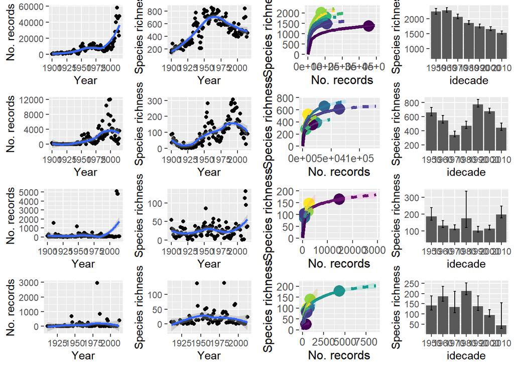

```r
## Multipanel figure for country-level analyses
grid.arrange(plot_us_recs, plot_us_sp,plot_chao_us,plot_est_us,
             plot_br_recs, plot_br_sp,plot_chao_br,plot_est_br,
             plot_gb_recs, plot_gb_sp,plot_chao_gb,plot_est_gb,
             plot_pa_recs, plot_pa_sp,plot_chao_pa,plot_est_pa,
             widths = c(2, 2, 2, 2),
             layout_matrix = rbind(c(1, 2, 3, 4),
                                   c(5, 6, 7, 8),
                                   c(9, 10, 11, 12),
                                   c(13, 14, 15, 16)))
```

The data reflects a clear and continuous decline in bee diversity in the USA<sup>18–20</sup> (with 1030029 records), a decline in Brazil<sup>21</sup> during the last two decades (188788 records), but shows no clear loss of richness in Great Britain (26885 records), and much uncertainty in an apparent trend in bee species loss in Panama (8892 records), despite reports of bee decline in all those countries.<sup>22–25</sup>

## Conclusions

One of the most important pieces of missing information of the global report on Pollinators, Pollination and Food Production of IPBES<sup>26</sup> was the lack of data on global bee decline, despite the many local and few regional reports pointing out that this decline could reflect a global phenomenon. Despite all its shortcomings, GBIF still is probably the best global data source available on long-term species occurrence and has the potential to contribute to filling this critical knowledge gap. Our analysis supports the hypothesis that we are undergoing a global decline in bee diversity that needs the immediate attention of governments and international institutions. Under the most optimistic interpretation – that bees are not declining, and that the trends we find are an artifact of data collection - our results would indicate that global efforts to record and monitor bee biodiversity are decreasing over time. However, and given the current outlook of global biodiversity,<sup>27–30</sup> it is more likely that these trends reflect existing scenarios of declining bee diversity. In the best scenario, this can indicate that thousands of bee species have become too rare; under the worst scenario, they may have already gone locally or globally extinct. In any case, a decline in bee diversity driven by either increasing rarity or irreversible extinction will affect the pollination of wild plants and crops, with broader ecological and economic consequences.<sup>30,31</sup> Slowing down and even reversing habitat destruction and land-conversion to intensive uses, implementation of environmentally friendly schemes in agricultural and urban settings, and programs to re-flower our world are urgently required. Bees cannot wait.

# References

1. GBIF.org (2020). (07 May 2020) GBIF occurrence download.

2. Michener, C.D. (2007). The bees of the world, 2nd edition.

3. Troudet, J., Vignes-Lebbe, R., Grandcolas, P., and Legendre, F. (2018). The increasing disconnection of primary biodiversity data from specimens: how does it happen and how to handle it? Systematic Biology *67*, 1110–1119.

4. Speed, J.D.M., Bendiksby, M., Finstad, A.G., Hassel, K., Kolstad, A.L., and Prestø, T. (2018). Contrasting spatial, temporal and environmental patterns in observation and specimen based species occurrence data. PLOS ONE *13*, e0196417.

5. Gaiji, S., Chavan, V., Ariño, A.H., Otegui, J., Hobern, D., Sood, R., and Robles, E. (2013). Content assessment of the primary biodiversity data published through GBIF network: Status, challenges and potentials. Biodiversity Informatics *8*.

6. Chao, A., Gotelli, N.J., Hsieh, T.C., Sander, E.L., Ma, K.H., Colwell, R.K., and Ellison, A.M. (2014). Rarefaction and extrapolation with Hill numbers: a framework for sampling and estimation in species diversity studies. Ecological Monographs *84*, 45–67.

7. Johnson, B.R., Borowiec, M.L., Chiu, J.C., Lee, E.K., Atallah, J., and Ward, P.S. (2013). Phylogenomics resolves evolutionary relationships among ants, bees, and wasps. Current Biology *23*, 2058–2062.

8. Hsieh, T.C., Ma, K.H., and Chao, A. (2016). iNEXT: an R package for rarefaction and extrapolation of species diversity (Hill numbers). Methods in Ecology and Evolution *7*, 1451–1456.

9. Wilson, E.O. (1971). The plight of taxonomy. Ecology *52*, 741–741.

10. Agnarsson, I., and Kuntner, M. (2007). Taxonomy in a changing world: seeking solutions for a science in crisis. Systematic Biology *56*, 531–539.

11. Carvalho, de M.R., Ebach, M.C., Williams, D.M., Nihei, S.S., Rodrigues, M.T., Grant, T., Silveira, L.F., Zaher, H., Gill, A.C., Schelly, R.C., et al. (2014). Does counting species count as taxonomy? On misrepresenting systematics, yet again. Cladistics *30*, 322–329.

12. Pielou, E.C. (1969). An introduction to mathematical ecology.

13. Bommarco, R., Lundin, O., Smith, H.G., and Rundlöf, M. (2012). Drastic historic shifts in bumble-bee community composition in Sweden. Proceedings of the Royal Society B: Biological Sciences *279*, 309–315.

14. Herrera, C.M. (2020). Gradual replacement of wild bees by honeybees in flowers of the Mediterranean Basin over the last 50 years. Proceedings of the Royal Society B: Biological Sciences *287*, 20192657.

15. Geslin, B., and Morales, C.L. (2015). New records reveal rapid geographic expansion of <i>Bombus terrestris</i> Linnaeus, 1758 (Hymenoptera: Apidae), an invasive species in Argentina. Check List *11*, 1620.

16. Aizen, M.A., and Harder, L.D. (2009). The global stock of domesticated honey bees Is growing slower than agricultural demand for pollination. Current Biology *19*, 915–918.

17. Garibaldi, L.A., Steffan-Dewenter, I., Winfree, R., Aizen, M.A., Bommarco, R., Cunningham, S.A., Kremen, C., Carvalheiro, L.G., Harder, L.D., Afik, O., et al. (2013). Wild pollinators enhance fruit set of crops regardless of honey bee abundance. Science *339*, 1608–1611.

18. Marlin, J.C., and LaBerge, W.E. (2001). The native bee fauna of Carlinville, Illinois, revisited after 75 years: a case for persistence. Conservation Ecology *5*.

19. Koh, I., Lonsdorf, E.V., Williams, N.M., Brittain, C., Isaacs, R., Gibbs, J., and Ricketts, T.H. (2016). Modeling the status, trends, and impacts of wild bee abundance in the United States. Proceedings of the National Academy of Sciences *113*, 140.

20. Gardner, J.D., and Spivak, M. (2014). A survey and historical comparison of the Megachilidae (Hymenoptera: Apoidea) of Itasca State Park, Minnesota. Annals of the Entomological Society of America *107*, 983–993.

21. Nemésio, A. (2013). Are orchid bees at risk? First comparative survey suggests declining populations of forest-dependent species. Brazilian Journal of Biology *73*, 367–374.

22. Biesmeijer, J.C., Roberts, S.P.M., Reemer, M., Ohlemüller, R., Edwards, M., Peeters, T., Schaffers, A.P., Potts, S.G., Kleukers, R., Thomas, C.D., et al. (2006). Parallel declines in pollinators and insect-pollinated plants in Britain and the Netherlands. Science *313*, 351–354.

23. Ollerton, J., Erenler, H., Edwards, M., and Crockett, R. (2014). Extinctions of aculeate pollinators in Britain and the role of large-scale agricultural changes. Science *346*, 1360–1362.

24. Powney, G.D., Carvell, C., Edwards, M., Morris, R.K.A., Roy, H.E., Woodcock, B.A., and Isaac, N.J.B. (2019). Widespread losses of pollinating insects in Britain. Nature Communications *10*, 1–6.

25. Vega-Hildago, Á., Añino, Y., Krichilsky, E., Smith, A.R., Santos-Murgas, A., and Gálvez, D. (2020). Decline of native bees (Apidae: Euglossa) in a tropical forest of Panama. Apidologie.

26. Potts, S.G., Ngo, H.T., Biesmeijer, J.C., Breeze, T.D., Dicks, L.V., Garibaldi, L.A., Hill, R., Settele, J., and Vanbergen, A. (2016). The assessment report of the Intergovernmental Science-Policy Platform on Biodiversity and Ecosystem Services on pollinators, pollination and food production.

27. Sánchez-Bayo, F., and Wyckhuys, K.A.G. (2019). Worldwide decline of the entomofauna: A review of its drivers. Biological Conservation *232*, 8–27.

28. Klink, van R., Bowler, D.E., Gongalsky, K.B., Swengel, A.B., Gentile, A., and Chase, J.M. (2020). Meta-analysis reveals declines in terrestrial but increases in freshwater insect abundances. Science *368*, 417–420.

29. IPBES (2019). Summary for policymakers of the global assessment report on biodiversity and ecosystem services of the Intergovernmental Science-Policy Platform on Biodiversity and Ecosystem Services S. Díaz, J. Settele, E. Brondízio, H. Ngo, M. Guèze, J. Agard, A. Arneth, P. Balvanera, K. Brauman, S. Butchart, et al., eds.

30. Potts, S.G., Biesmeijer, J.C., Kremen, C., Neumann, P., Schweiger, O., and Kunin, W.E. (2010). Global pollinator declines: trends, impacts and drivers. Trends in Ecology & Evolution *25*, 345–353.

31. Vanbergen, A.J., and Insect Pollinators Initiative (2013). Threats to an ecosystem service: pressures on pollinators. Frontiers in Ecology and the Environment *11*, 251–259.